# Risk Factor Analysis

## Outcome Variable

**Outcome Variable:** haz

## Predictor Variables

**Intervention Variable:** perdiar6

**Adjustment Set:**

- arm
- sex
- W_mage
- meducyrs
- feducyrs
- hhwealth_quart
- hfoodsec
- W_mhtcm
- W_mwtkg
- W_mbmi
- W_birthwt
- W_birthlen
- W_nrooms
- month
- brthmon
- impfloor
- impsan
- safeh20
- delta_W_mage
- delta_meducyrs
- delta_feducyrs
- delta_hhwealth_quart
- delta_hfoodsec
- delta_W_mhtcm
- delta_W_mwtkg
- delta_W_mbmi
- delta_W_birthwt
- delta_W_birthlen
- delta_W_nrooms
- delta_month
- delta_brthmon
- delta_impfloor
- delta_impsan
- delta_safeh20

## Stratifying Variables

The analysis was stratified on these variable(s):

- agecat
- studyid
- country

## Data Summary

| agecat | studyid | country | perdiar6 | n_cell | n |
| --- | --- | --- | --- | --- | --- |
| Birth | ki0047075b-MAL-ED | BANGLADESH | 0% | 72 | 231 |
| Birth | ki0047075b-MAL-ED | BANGLADESH | (0%, 5%] | 90 | 231 |
| Birth | ki0047075b-MAL-ED | BANGLADESH | >5% | 69 | 231 |
| Birth | ki0047075b-MAL-ED | BRAZIL | 0% | 57 | 65 |
| Birth | ki0047075b-MAL-ED | BRAZIL | (0%, 5%] | 6 | 65 |
| Birth | ki0047075b-MAL-ED | BRAZIL | >5% | 2 | 65 |
| Birth | ki0047075b-MAL-ED | INDIA | 0% | 12 | 47 |
| Birth | ki0047075b-MAL-ED | INDIA | (0%, 5%] | 24 | 47 |
| Birth | ki0047075b-MAL-ED | INDIA | >5% | 11 | 47 |
| Birth | ki0047075b-MAL-ED | NEPAL | 0% | 8 | 27 |
| Birth | ki0047075b-MAL-ED | NEPAL | (0%, 5%] | 10 | 27 |
| Birth | ki0047075b-MAL-ED | NEPAL | >5% | 9 | 27 |
| Birth | ki0047075b-MAL-ED | PERU | 0% | 67 | 233 |
| Birth | ki0047075b-MAL-ED | PERU | (0%, 5%] | 72 | 233 |
| Birth | ki0047075b-MAL-ED | PERU | >5% | 94 | 233 |
| Birth | ki0047075b-MAL-ED | SOUTH AFRICA | 0% | 86 | 113 |
| Birth | ki0047075b-MAL-ED | SOUTH AFRICA | (0%, 5%] | 23 | 113 |
| Birth | ki0047075b-MAL-ED | SOUTH AFRICA | >5% | 4 | 113 |
| Birth | ki0047075b-MAL-ED | TANZANIA, UNITED REPUBLIC OF | 0% | 59 | 125 |
| Birth | ki0047075b-MAL-ED | TANZANIA, UNITED REPUBLIC OF | (0%, 5%] | 45 | 125 |
| Birth | ki0047075b-MAL-ED | TANZANIA, UNITED REPUBLIC OF | >5% | 21 | 125 |
| Birth | ki1000109-EE | PAKISTAN | 0% | 223 | 240 |
| Birth | ki1000109-EE | PAKISTAN | (0%, 5%] | 15 | 240 |
| Birth | ki1000109-EE | PAKISTAN | >5% | 2 | 240 |
| Birth | ki1017093-NIH-Birth | BANGLADESH | 0% | 160 | 605 |
| Birth | ki1017093-NIH-Birth | BANGLADESH | (0%, 5%] | 177 | 605 |
| Birth | ki1017093-NIH-Birth | BANGLADESH | >5% | 268 | 605 |
| Birth | ki1017093b-PROVIDE | BANGLADESH | 0% | 161 | 539 |
| Birth | ki1017093b-PROVIDE | BANGLADESH | (0%, 5%] | 209 | 539 |
| Birth | ki1017093b-PROVIDE | BANGLADESH | >5% | 169 | 539 |

[output cut: 87 more lines]

The following strata were considered:

- agecat: 24 months, studyid: ki0047075b-MAL-ED, country: BANGLADESH
- agecat: 24 months, studyid: ki0047075b-MAL-ED, country: BRAZIL
- agecat: 24 months, studyid: ki0047075b-MAL-ED, country: INDIA
- agecat: 24 months, studyid: ki0047075b-MAL-ED, country: NEPAL
- agecat: 24 months, studyid: ki0047075b-MAL-ED, country: PERU
- agecat: 24 months, studyid: ki0047075b-MAL-ED, country: SOUTH AFRICA
- agecat: 24 months, studyid: ki0047075b-MAL-ED, country: TANZANIA, UNITED REPUBLIC OF
- agecat: 24 months, studyid: ki1000109-EE, country: PAKISTAN
- agecat: 24 months, studyid: ki1017093-NIH-Birth, country: BANGLADESH
- agecat: 24 months, studyid: ki1017093b-PROVIDE, country: BANGLADESH
- agecat: 24 months, studyid: ki1017093c-NIH-Crypto, country: BANGLADESH
- agecat: 24 months, studyid: ki1114097-CMIN, country: BANGLADESH
- agecat: 24 months, studyid: ki1114097-CONTENT, country: PERU
- agecat: 6 months, studyid: ki0047075b-MAL-ED, country: BANGLADESH
- agecat: 6 months, studyid: ki0047075b-MAL-ED, country: BRAZIL
- agecat: 6 months, studyid: ki0047075b-MAL-ED, country: INDIA
- agecat: 6 months, studyid: ki0047075b-MAL-ED, country: NEPAL
- agecat: 6 months, studyid: ki0047075b-MAL-ED, country: PERU
- agecat: 6 months, studyid: ki0047075b-MAL-ED, country: SOUTH AFRICA
- agecat: 6 months, studyid: ki0047075b-MAL-ED, country: TANZANIA, UNITED REPUBLIC OF
- agecat: 6 months, studyid: ki1000109-EE, country: PAKISTAN
- agecat: 6 months, studyid: ki1017093-NIH-Birth, country: BANGLADESH
- agecat: 6 months, studyid: ki1017093b-PROVIDE, country: BANGLADESH
- agecat: 6 months, studyid: ki1017093c-NIH-Crypto, country: BANGLADESH
- agecat: 6 months, studyid: ki1114097-CMIN, country: BANGLADESH
- agecat: 6 months, studyid: ki1114097-CONTENT, country: PERU
- agecat: Birth, studyid: ki0047075b-MAL-ED, country: BANGLADESH
- agecat: Birth, studyid: ki0047075b-MAL-ED, country: BRAZIL
- agecat: Birth, studyid: ki0047075b-MAL-ED, country: INDIA
- agecat: Birth, studyid: ki0047075b-MAL-ED, country: NEPAL
- agecat: Birth, studyid: ki0047075b-MAL-ED, country: PERU
- agecat: Birth, studyid: ki0047075b-MAL-ED, country: SOUTH AFRICA
- agecat: Birth, studyid: ki0047075b-MAL-ED, country: TANZANIA, UNITED REPUBLIC OF
- agecat: Birth, studyid: ki1000109-EE, country: PAKISTAN
- agecat: Birth, studyid: ki1017093-NIH-Birth, country: BANGLADESH
- agecat: Birth, studyid: ki1017093b-PROVIDE, country: BANGLADESH
- agecat: Birth, studyid: ki1017093c-NIH-Crypto, country: BANGLADESH
- agecat: Birth, studyid: ki1114097-CMIN, country: BANGLADESH
- agecat: Birth, studyid: ki1114097-CONTENT, country: PERU

### Dropped Strata

Some strata were dropped due to rare outcomes:

- agecat: Birth, studyid: ki0047075b-MAL-ED, country: BRAZIL
- agecat: Birth, studyid: ki0047075b-MAL-ED, country: SOUTH AFRICA
- agecat: Birth, studyid: ki1000109-EE, country: PAKISTAN
- agecat: Birth, studyid: ki1114097-CMIN, country: BANGLADESH
- agecat: Birth, studyid: ki1114097-CONTENT, country: PERU
- agecat: 6 months, studyid: ki0047075b-MAL-ED, country: BRAZIL
- agecat: 6 months, studyid: ki1000109-EE, country: PAKISTAN
- agecat: 24 months, studyid: ki0047075b-MAL-ED, country: BRAZIL
- agecat: 24 months, studyid: ki1000109-EE, country: PAKISTAN

## Methods Detail

We’re interested in the causal parameters $E[Y_a]$ for all values of $a \in \mathcal{A}$. These parameters represent the mean outcome if, possibly contrary to fact, we intervened to set all units to have $A=a$. Under the randomization and positivity assumptions, these are identified by the statistical parameters $\psi_a=E_W[E_{Y|A,W}(Y|A=a,W)]$. In addition, we’re interested in the mean of $Y$, $E[Y]$ under no intervention (the observed mean). We will estimate these parameters by using SuperLearner to fit the relevant likelihood factors – $E_{Y|A,W}(Y|A=a,W)$ and $p(A=a|W)$, and then updating our likelihood fit using a joint TMLE.

For unadjusted analyses ($W=\{\}$), initial likelihoods were estimated using Lrnr_glm to estimate the simple $E(Y|A)$ and Lrnr_mean to estimate $p(A)$. For adjusted analyses, a small library containing Lrnr_glmnet, Lrnr_xgboost, and Lrnr_mean was used.

Having estimated these parameters, we will then use the delta method to estimate relative risks and attributable risks relative to a prespecified baseline level of $A$.

# Results Detail

## Results Plots

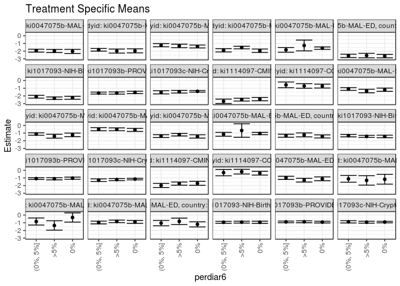

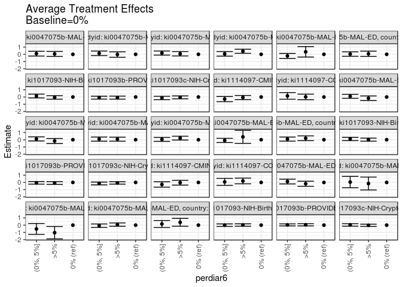

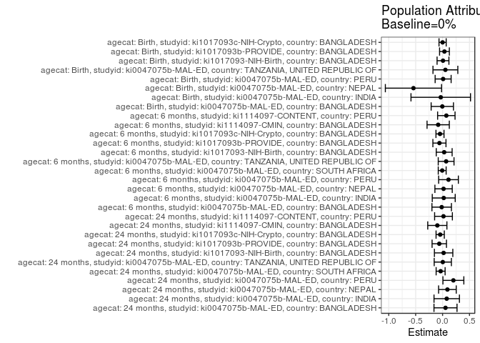

## Results Table

### Parameter: TSM

| agecat | studyid | country | intervention_level | baseline_level | estimate | ci_lower | ci_upper |
| --- | --- | --- | --- | --- | --- | --- | --- |
| Birth | ki0047075b-MAL-ED | BANGLADESH | 0% | NA | -1.1130406 | -1.3658101 | -0.8602710 |
| Birth | ki0047075b-MAL-ED | BANGLADESH | (0%, 5%] | NA | -0.9879146 | -1.2001473 | -0.7756819 |
| Birth | ki0047075b-MAL-ED | BANGLADESH | >5% | NA | -1.2945427 | -1.5362444 | -1.0528410 |
| Birth | ki0047075b-MAL-ED | INDIA | 0% | NA | -1.1696987 | -1.8093537 | -0.5300438 |
| Birth | ki0047075b-MAL-ED | INDIA | (0%, 5%] | NA | -1.1186064 | -1.5561524 | -0.6810603 |
| Birth | ki0047075b-MAL-ED | INDIA | >5% | NA | -1.3201538 | -1.9349408 | -0.7053667 |
| Birth | ki0047075b-MAL-ED | NEPAL | 0% | NA | -0.3125000 | -0.9090602 | 0.2840602 |
| Birth | ki0047075b-MAL-ED | NEPAL | (0%, 5%] | NA | -0.8360000 | -1.2964736 | -0.3755264 |
| Birth | ki0047075b-MAL-ED | NEPAL | >5% | NA | -1.3533333 | -1.9688465 | -0.7378201 |
| Birth | ki0047075b-MAL-ED | PERU | 0% | NA | -0.8931055 | -1.0803656 | -0.7058454 |
| Birth | ki0047075b-MAL-ED | PERU | (0%, 5%] | NA | -0.9697808 | -1.1468855 | -0.7926761 |
| Birth | ki0047075b-MAL-ED | PERU | >5% | NA | -0.8201458 | -0.9823348 | -0.6579567 |
| Birth | ki0047075b-MAL-ED | TANZANIA, UNITED REPUBLIC OF | 0% | NA | -1.2079417 | -1.5426745 | -0.8732090 |
| Birth | ki0047075b-MAL-ED | TANZANIA, UNITED REPUBLIC OF | (0%, 5%] | NA | -1.0473505 | -1.3911899 | -0.7035110 |
| Birth | ki0047075b-MAL-ED | TANZANIA, UNITED REPUBLIC OF | >5% | NA | -0.8138980 | -1.2326321 | -0.3951638 |
| Birth | ki1017093-NIH-Birth | BANGLADESH | 0% | NA | -0.9392062 | -1.0792756 | -0.7991367 |
| Birth | ki1017093-NIH-Birth | BANGLADESH | (0%, 5%] | NA | -0.9392625 | -1.0664792 | -0.8120458 |
| Birth | ki1017093-NIH-Birth | BANGLADESH | >5% | NA | -0.9229957 | -1.0452539 | -0.8007375 |
| Birth | ki1017093b-PROVIDE | BANGLADESH | 0% | NA | -0.9200951 | -1.0327669 | -0.8074232 |
| Birth | ki1017093b-PROVIDE | BANGLADESH | (0%, 5%] | NA | -0.8864105 | -0.9918499 | -0.7809712 |
| Birth | ki1017093b-PROVIDE | BANGLADESH | >5% | NA | -0.8724540 | -0.9965735 | -0.7483344 |
| Birth | ki1017093c-NIH-Crypto | BANGLADESH | 0% | NA | -0.9097600 | -1.0088473 | -0.8106727 |
| Birth | ki1017093c-NIH-Crypto | BANGLADESH | (0%, 5%] | NA | -0.8809722 | -1.0288511 | -0.7330933 |
| Birth | ki1017093c-NIH-Crypto | BANGLADESH | >5% | NA | -0.9287594 | -1.0539282 | -0.8035905 |
| 6 months | ki0047075b-MAL-ED | BANGLADESH | 0% | NA | -1.1883792 | -1.4018175 | -0.9749410 |
| 6 months | ki0047075b-MAL-ED | BANGLADESH | (0%, 5%] | NA | -1.0927203 | -1.2692491 | -0.9161916 |
| 6 months | ki0047075b-MAL-ED | BANGLADESH | >5% | NA | -1.3567207 | -1.5883342 | -1.1251073 |
| 6 months | ki0047075b-MAL-ED | INDIA | 0% | NA | -1.2330064 | -1.4674110 | -0.9986017 |
| 6 months | ki0047075b-MAL-ED | INDIA | (0%, 5%] | NA | -1.1198383 | -1.2789947 | -0.9606820 |
| 6 months | ki0047075b-MAL-ED | INDIA | >5% | NA | -1.4073876 | -1.6623518 | -1.1524235 |

[output cut: 60 more lines]

### Parameter: E(Y)

| agecat | studyid | country | intervention_level | baseline_level | estimate | ci_lower | ci_upper |
| --- | --- | --- | --- | --- | --- | --- | --- |
| Birth | ki0047075b-MAL-ED | BANGLADESH | NA | NA | -1.1180952 | -1.2525408 | -0.9836496 |
| Birth | ki0047075b-MAL-ED | INDIA | NA | NA | -1.2036170 | -1.4976814 | -0.9095527 |
| Birth | ki0047075b-MAL-ED | NEPAL | NA | NA | -0.8533333 | -1.2104864 | -0.4961803 |
| Birth | ki0047075b-MAL-ED | PERU | NA | NA | -0.8827897 | -1.0001058 | -0.7654736 |
| Birth | ki0047075b-MAL-ED | TANZANIA, UNITED REPUBLIC OF | NA | NA | -1.1556000 | -1.3655361 | -0.9456639 |
| Birth | ki1017093-NIH-Birth | BANGLADESH | NA | NA | -0.9314050 | -1.0202164 | -0.8425936 |
| Birth | ki1017093b-PROVIDE | BANGLADESH | NA | NA | -0.8851020 | -0.9601332 | -0.8100709 |
| Birth | ki1017093c-NIH-Crypto | BANGLADESH | NA | NA | -0.9094945 | -0.9809370 | -0.8380521 |
| 6 months | ki0047075b-MAL-ED | BANGLADESH | NA | NA | -1.2049931 | -1.3222136 | -1.0877726 |
| 6 months | ki0047075b-MAL-ED | INDIA | NA | NA | -1.2115254 | -1.3298727 | -1.0931782 |
| 6 months | ki0047075b-MAL-ED | NEPAL | NA | NA | -0.5615819 | -0.6741832 | -0.4489807 |
| 6 months | ki0047075b-MAL-ED | PERU | NA | NA | -1.3236661 | -1.4316775 | -1.2156546 |
| 6 months | ki0047075b-MAL-ED | SOUTH AFRICA | NA | NA | -1.0633202 | -1.1909180 | -0.9357224 |
| 6 months | ki0047075b-MAL-ED | TANZANIA, UNITED REPUBLIC OF | NA | NA | -1.3687449 | -1.4907629 | -1.2467270 |
| 6 months | ki1017093-NIH-Birth | BANGLADESH | NA | NA | -1.4073821 | -1.4960598 | -1.3187043 |
| 6 months | ki1017093b-PROVIDE | BANGLADESH | NA | NA | -1.0916915 | -1.1661176 | -1.0172654 |
| 6 months | ki1017093c-NIH-Crypto | BANGLADESH | NA | NA | -1.1986783 | -1.2700937 | -1.1272630 |
| 6 months | ki1114097-CMIN | BANGLADESH | NA | NA | -1.7844376 | -1.9222926 | -1.6465825 |
| 6 months | ki1114097-CONTENT | PERU | NA | NA | -0.3139217 | -0.4868486 | -0.1409948 |
| 24 months | ki0047075b-MAL-ED | BANGLADESH | NA | NA | -1.9783962 | -2.1050210 | -1.8517715 |
| 24 months | ki0047075b-MAL-ED | INDIA | NA | NA | -1.8861894 | -2.0110006 | -1.7613783 |
| 24 months | ki0047075b-MAL-ED | NEPAL | NA | NA | -1.3075877 | -1.4270718 | -1.1881037 |
| 24 months | ki0047075b-MAL-ED | PERU | NA | NA | -1.7524710 | -1.8736426 | -1.6312994 |
| 24 months | ki0047075b-MAL-ED | SOUTH AFRICA | NA | NA | -1.6450595 | -1.7797240 | -1.5103950 |
| 24 months | ki0047075b-MAL-ED | TANZANIA, UNITED REPUBLIC OF | NA | NA | -2.6455607 | -2.7807256 | -2.5103959 |
| 24 months | ki1017093-NIH-Birth | BANGLADESH | NA | NA | -2.2190579 | -2.3217459 | -2.1163699 |
| 24 months | ki1017093b-PROVIDE | BANGLADESH | NA | NA | -1.6024221 | -1.6857420 | -1.5191023 |
| 24 months | ki1017093c-NIH-Crypto | BANGLADESH | NA | NA | -1.4412646 | -1.5249156 | -1.3576135 |
| 24 months | ki1114097-CMIN | BANGLADESH | NA | NA | -2.5109504 | -2.6361514 | -2.3857494 |
| 24 months | ki1114097-CONTENT | PERU | NA | NA | -0.6962195 | -0.8674103 | -0.5250287 |

### Parameter: ATE

| agecat | studyid | country | intervention_level | baseline_level | estimate | ci_lower | ci_upper |
| --- | --- | --- | --- | --- | --- | --- | --- |
| Birth | ki0047075b-MAL-ED | BANGLADESH | 0% | 0% | 0.0000000 | 0.0000000 | 0.0000000 |
| Birth | ki0047075b-MAL-ED | BANGLADESH | (0%, 5%] | 0% | 0.1251260 | -0.2051967 | 0.4554486 |
| Birth | ki0047075b-MAL-ED | BANGLADESH | >5% | 0% | -0.1815021 | -0.5315993 | 0.1685950 |
| Birth | ki0047075b-MAL-ED | INDIA | 0% | 0% | 0.0000000 | 0.0000000 | 0.0000000 |
| Birth | ki0047075b-MAL-ED | INDIA | (0%, 5%] | 0% | 0.0510924 | -0.7278583 | 0.8300430 |
| Birth | ki0047075b-MAL-ED | INDIA | >5% | 0% | -0.1504550 | -1.0389196 | 0.7380095 |
| Birth | ki0047075b-MAL-ED | NEPAL | 0% | 0% | 0.0000000 | 0.0000000 | 0.0000000 |
| Birth | ki0047075b-MAL-ED | NEPAL | (0%, 5%] | 0% | -0.5235000 | -1.2771047 | 0.2301047 |
| Birth | ki0047075b-MAL-ED | NEPAL | >5% | 0% | -1.0408333 | -1.8980034 | -0.1836633 |
| Birth | ki0047075b-MAL-ED | PERU | 0% | 0% | 0.0000000 | 0.0000000 | 0.0000000 |
| Birth | ki0047075b-MAL-ED | PERU | (0%, 5%] | 0% | -0.0766753 | -0.3164900 | 0.1631394 |
| Birth | ki0047075b-MAL-ED | PERU | >5% | 0% | 0.0729597 | -0.1536944 | 0.2996139 |
| Birth | ki0047075b-MAL-ED | TANZANIA, UNITED REPUBLIC OF | 0% | 0% | 0.0000000 | 0.0000000 | 0.0000000 |
| Birth | ki0047075b-MAL-ED | TANZANIA, UNITED REPUBLIC OF | (0%, 5%] | 0% | 0.1605913 | -0.3213677 | 0.6425502 |
| Birth | ki0047075b-MAL-ED | TANZANIA, UNITED REPUBLIC OF | >5% | 0% | 0.3940438 | -0.1489703 | 0.9370578 |
| Birth | ki1017093-NIH-Birth | BANGLADESH | 0% | 0% | 0.0000000 | 0.0000000 | 0.0000000 |
| Birth | ki1017093-NIH-Birth | BANGLADESH | (0%, 5%] | 0% | -0.0000563 | -0.1719486 | 0.1718360 |
| Birth | ki1017093-NIH-Birth | BANGLADESH | >5% | 0% | 0.0162105 | -0.1491628 | 0.1815838 |
| Birth | ki1017093b-PROVIDE | BANGLADESH | 0% | 0% | 0.0000000 | 0.0000000 | 0.0000000 |
| Birth | ki1017093b-PROVIDE | BANGLADESH | (0%, 5%] | 0% | 0.0336845 | -0.1075642 | 0.1749333 |
| Birth | ki1017093b-PROVIDE | BANGLADESH | >5% | 0% | 0.0476411 | -0.1068655 | 0.2021477 |
| Birth | ki1017093c-NIH-Crypto | BANGLADESH | 0% | 0% | 0.0000000 | 0.0000000 | 0.0000000 |
| Birth | ki1017093c-NIH-Crypto | BANGLADESH | (0%, 5%] | 0% | 0.0287878 | -0.1450668 | 0.2026424 |
| Birth | ki1017093c-NIH-Crypto | BANGLADESH | >5% | 0% | -0.0189994 | -0.1741339 | 0.1361352 |
| 6 months | ki0047075b-MAL-ED | BANGLADESH | 0% | 0% | 0.0000000 | 0.0000000 | 0.0000000 |
| 6 months | ki0047075b-MAL-ED | BANGLADESH | (0%, 5%] | 0% | 0.0956589 | -0.1807463 | 0.3720640 |
| 6 months | ki0047075b-MAL-ED | BANGLADESH | >5% | 0% | -0.1683415 | -0.4848505 | 0.1481675 |
| 6 months | ki0047075b-MAL-ED | INDIA | 0% | 0% | 0.0000000 | 0.0000000 | 0.0000000 |
| 6 months | ki0047075b-MAL-ED | INDIA | (0%, 5%] | 0% | 0.1131680 | -0.1701361 | 0.3964721 |
| 6 months | ki0047075b-MAL-ED | INDIA | >5% | 0% | -0.1743813 | -0.5213981 | 0.1726356 |

[output cut: 60 more lines]

### Parameter: PAR

| agecat | studyid | country | intervention_level | baseline_level | estimate | ci_lower | ci_upper |
| --- | --- | --- | --- | --- | --- | --- | --- |
| Birth | ki0047075b-MAL-ED | BANGLADESH | 0% | NA | -0.0050547 | -0.2122643 | 0.2021550 |
| Birth | ki0047075b-MAL-ED | INDIA | 0% | NA | -0.0339183 | -0.5868994 | 0.5190627 |
| Birth | ki0047075b-MAL-ED | NEPAL | 0% | NA | -0.5408333 | -1.0628947 | -0.0187719 |
| Birth | ki0047075b-MAL-ED | PERU | 0% | NA | 0.0103158 | -0.1380591 | 0.1586907 |
| Birth | ki0047075b-MAL-ED | TANZANIA, UNITED REPUBLIC OF | 0% | NA | 0.0523417 | -0.1785100 | 0.2831934 |
| Birth | ki1017093-NIH-Birth | BANGLADESH | 0% | NA | 0.0078012 | -0.1021652 | 0.1177677 |
| Birth | ki1017093b-PROVIDE | BANGLADESH | 0% | NA | 0.0349930 | -0.0557415 | 0.1257275 |
| Birth | ki1017093c-NIH-Crypto | BANGLADESH | 0% | NA | 0.0002655 | -0.0663563 | 0.0668872 |
| 6 months | ki0047075b-MAL-ED | BANGLADESH | 0% | NA | -0.0166138 | -0.1976422 | 0.1644145 |
| 6 months | ki0047075b-MAL-ED | INDIA | 0% | NA | 0.0214809 | -0.1916168 | 0.2345787 |
| 6 months | ki0047075b-MAL-ED | NEPAL | 0% | NA | 0.0184083 | -0.1425855 | 0.1794021 |
| 6 months | ki0047075b-MAL-ED | PERU | 0% | NA | 0.1098991 | -0.0731877 | 0.2929860 |
| 6 months | ki0047075b-MAL-ED | SOUTH AFRICA | 0% | NA | -0.0071009 | -0.0803127 | 0.0661109 |
| 6 months | ki0047075b-MAL-ED | TANZANIA, UNITED REPUBLIC OF | 0% | NA | 0.0658741 | -0.0806223 | 0.2123706 |
| 6 months | ki1017093-NIH-Birth | BANGLADESH | 0% | NA | 0.0298597 | -0.1176207 | 0.1773401 |
| 6 months | ki1017093b-PROVIDE | BANGLADESH | 0% | NA | -0.0584186 | -0.1801084 | 0.0632712 |
| 6 months | ki1017093c-NIH-Crypto | BANGLADESH | 0% | NA | -0.0480979 | -0.1227666 | 0.0265709 |
| 6 months | ki1114097-CMIN | BANGLADESH | 0% | NA | -0.0817162 | -0.2883861 | 0.1249536 |
| 6 months | ki1114097-CONTENT | PERU | 0% | NA | 0.0695868 | -0.0921656 | 0.2313393 |
| 24 months | ki0047075b-MAL-ED | BANGLADESH | 0% | NA | 0.0544145 | -0.1597210 | 0.2685500 |
| 24 months | ki0047075b-MAL-ED | INDIA | 0% | NA | 0.0769053 | -0.1591567 | 0.3129672 |
| 24 months | ki0047075b-MAL-ED | NEPAL | 0% | NA | 0.0897586 | -0.0739654 | 0.2534825 |
| 24 months | ki0047075b-MAL-ED | PERU | 0% | NA | 0.2006123 | 0.0064024 | 0.3948222 |
| 24 months | ki0047075b-MAL-ED | SOUTH AFRICA | 0% | NA | -0.0363213 | -0.1197270 | 0.0470845 |
| 24 months | ki0047075b-MAL-ED | TANZANIA, UNITED REPUBLIC OF | 0% | NA | 0.0040277 | -0.1555600 | 0.1636154 |
| 24 months | ki1017093-NIH-Birth | BANGLADESH | 0% | NA | 0.0192472 | -0.1516467 | 0.1901411 |
| 24 months | ki1017093b-PROVIDE | BANGLADESH | 0% | NA | -0.0613848 | -0.1950364 | 0.0722668 |
| 24 months | ki1017093c-NIH-Crypto | BANGLADESH | 0% | NA | -0.0445155 | -0.1211150 | 0.0320841 |
| 24 months | ki1114097-CMIN | BANGLADESH | 0% | NA | -0.0976751 | -0.2756081 | 0.0802580 |
| 24 months | ki1114097-CONTENT | PERU | 0% | NA | 0.0171088 | -0.1477919 | 0.1820095 |